# Beispiel-Analyse: Titanic-Datensatz

Tom Alby / Matrikelnummer 123456789

2026-06-05

## 1 Datensatz: Herkunft & Erhebung

Der **Titanic-Datensatz** enthält Passagierdaten der RMS Titanic, die am 15. April 1912 nach einer Kollision mit einem Eisberg sank. Von 2.224 Personen an Bord überlebten nur 710.

Die Daten wurden aus dem Untersuchungsbericht des *British Board of Trade* sowie aus der Datenbank [Encyclopedia Titanica](https://www.encyclopedia-titanica.org/) zusammengestellt. Die hier verwendete Version stammt von der Kaggle-Plattform (ursprünglich von Vanderbilt University, Biostatistics Dept.) und ist ein Standarddatensatz für Lehr- und Lernzwecke in der Datenanalyse.

**Variablen (Auswahl):**

| Variable | Beschreibung | Skalenniveau |
| --- | --- | --- |
| `pclass` | Ticketklasse (1 = 1. Klasse, 2 = 2. Klasse, 3 = 3. Klasse) | ordinal |
| `survived` | Überlebt (1 = ja, 0 = nein) | nominal |
| `sex` | Geschlecht | nominal |
| `age` | Alter in Jahren | verhältnis |
| `fare` | Ticketpreis in britischen Pfund | verhältnis |
| `sibsp` | Anzahl Geschwister / Ehepartner an Bord | verhältnis |
| `parch` | Anzahl Eltern / Kinder an Bord | verhältnis |
| `embarked` | Einschiffungshafen (S = Southampton, C = Cherbourg, Q = Queenstown) | nominal |

## 2 Daten laden & aufbereiten

```r
titanic <- read.csv2("data/titanic.csv", stringsAsFactors = FALSE)

# Relevante Variablen bereinigen
titanic <- titanic |>
  mutate(
    survived  = factor(survived, levels = c(0, 1), labels = c("Nein", "Ja")),
    pclass    = factor(pclass, levels = c(1, 2, 3), labels = c("1. Klasse", "2. Klasse", "3. Klasse")),
    sex       = factor(sex, levels = c("female", "male"), labels = c("weiblich", "männlich")),
    age       = as.numeric(age),
    fare      = as.numeric(fare)
  )

glimpse(titanic)
```

```
## Rows: 1,310
## Columns: 14
## $ pclass    <fct> 1. Klasse, 1. Klasse, 1. Klasse, 1. Klasse, 1. Klasse, 1. Kl…
## $ survived  <fct> Ja, Ja, Nein, Nein, Nein, Ja, Ja, Nein, Ja, Nein, Nein, Ja, …
## $ name      <chr> "Allen, Miss. Elisabeth Walton", "Allison, Master. Hudson Tr…
## $ sex       <fct> weiblich, männlich, weiblich, männlich, weiblich, männlich, …
## $ age       <dbl> 29.0000, 0.9167, 2.0000, 30.0000, 25.0000, 48.0000, 63.0000,…
## $ sibsp     <int> 0, 1, 1, 1, 1, 0, 1, 0, 2, 0, 1, 1, 0, 0, 0, 0, 0, 0, 0, 0, …
## $ parch     <int> 0, 2, 2, 2, 2, 0, 0, 0, 0, 0, 0, 0, 0, 0, 0, 0, 1, 1, 0, 0, …
## $ ticket    <chr> "24160", "113781", "113781", "113781", "113781", "19952", "1…
## $ fare      <dbl> 211.3375, 151.5500, 151.5500, 151.5500, 151.5500, 26.5500, 7…
## $ cabin     <chr> "B5", "C22 C26", "C22 C26", "C22 C26", "C22 C26", "E12", "D7…
## $ embarked  <chr> "S", "S", "S", "S", "S", "S", "S", "S", "S", "C", "C", "C", …
## $ boat      <chr> "2", "11", "", "", "", "3", "10", "", "D", "", "", "4", "9",…
## $ body      <int> NA, NA, NA, 135, NA, NA, NA, NA, NA, 22, 124, NA, NA, NA, NA…
## $ home.dest <chr> "St Louis, MO", "Montreal, PQ / Chesterville, ON", "Montreal…
```

## 3 Deskriptive Statistik

### 3.1 Stichprobengröße & fehlende Werte

```r
cat("Passagiere gesamt:", nrow(titanic), "\n")
```

```
## Passagiere gesamt: 1310
```

```r
cat("Fehlende Werte (Alter):", sum(is.na(titanic$age)), "\n")
```

```
## Fehlende Werte (Alter): 264
```

```r
cat("Fehlende Werte (Ticketpreis):", sum(is.na(titanic$fare)), "\n")
```

```
## Fehlende Werte (Ticketpreis): 2
```

### 3.2 Überlebensrate

```r
titanic |>
  count(survived) |>
  mutate(Anteil = round(n / sum(n) * 100, 1))
```

| survived | n | Anteil |
| --- | --- | --- |
| Nein | 809 | 61.8 |
| Ja | 500 | 38.2 |
| NA | 1 | 0.1 |

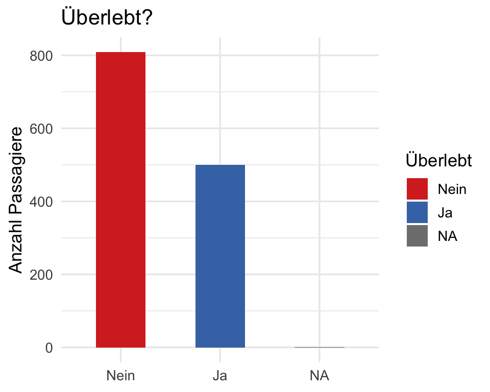

```r
ggplot(titanic, aes(x = survived, fill = survived)) +
  geom_bar(width = 0.5) +
  scale_fill_manual(values = c("Nein" = "#d73027", "Ja" = "#4575b4")) +
  labs(title = "Überlebt?", x = NULL, y = "Anzahl Passagiere", fill = "Überlebt") +
  theme_minimal(base_size = 13)
```

### 3.3 Überlebensrate nach Klasse und Geschlecht

```r
titanic |>
  group_by(pclass, sex) |>
  summarise(
    n         = n(),
    überlebt  = sum(survived == "Ja"),
    Rate_Proz = round(überlebt / n * 100, 1)
  )
```

| pclass | sex | n | überlebt | Rate_Proz |
| --- | --- | --- | --- | --- |
| 1. Klasse | weiblich | 144 | 139 | 96.5 |
| 1. Klasse | männlich | 179 | 61 | 34.1 |
| 2. Klasse | weiblich | 106 | 94 | 88.7 |
| 2. Klasse | männlich | 171 | 25 | 14.6 |
| 3. Klasse | weiblich | 216 | 106 | 49.1 |
| 3. Klasse | männlich | 493 | 75 | 15.2 |
| NA | NA | 1 | NA | NA |

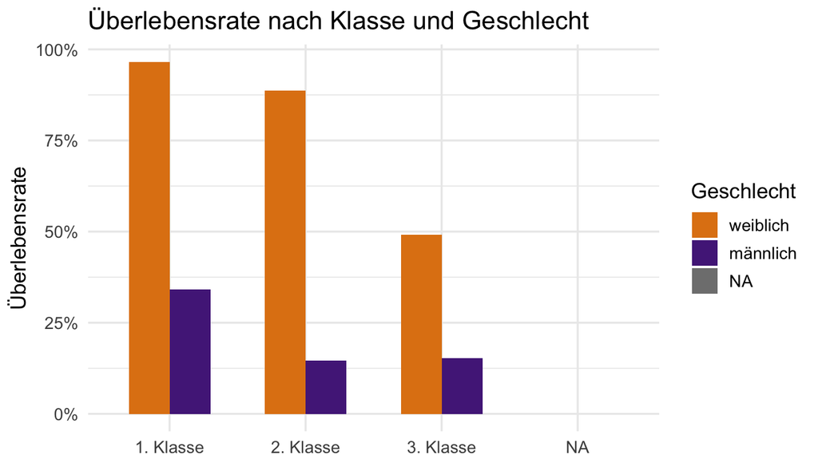

```r
titanic |>
  group_by(pclass, sex) |>
  summarise(rate = mean(survived == "Ja")) |>
  ggplot(aes(x = pclass, y = rate, fill = sex)) +
  geom_col(position = "dodge", width = 0.6) +
  scale_y_continuous(labels = scales::percent) +
  scale_fill_manual(values = c("weiblich" = "#e08214", "männlich" = "#542788")) +
  labs(title = "Überlebensrate nach Klasse und Geschlecht",
       x = NULL, y = "Überlebensrate", fill = "Geschlecht") +
  theme_minimal(base_size = 13)
```

### 3.4 Altersverteilung

```r
titanic |>
  filter(!is.na(age)) |>
  summarise(
    n      = n(),
    Mittel = round(mean(age), 1),
    SD     = round(sd(age), 1),
    Min    = min(age),
    Median = median(age),
    Max    = max(age)
  )
```

| n | Mittel | SD | Min | Median | Max |
| --- | --- | --- | --- | --- | --- |
| 1046 | 29.9 | 14.4 | 0.1667 | 28 | 80 |

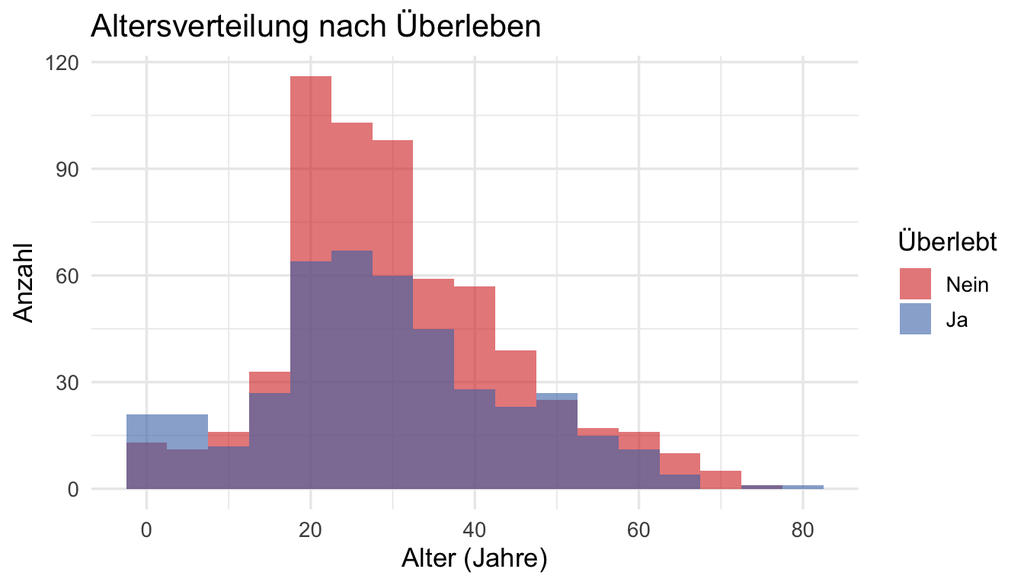

```r
titanic |>
  filter(!is.na(age)) |>
  ggplot(aes(x = age, fill = survived)) +
  geom_histogram(binwidth = 5, position = "identity", alpha = 0.6) +
  scale_fill_manual(values = c("Nein" = "#d73027", "Ja" = "#4575b4")) +
  labs(title = "Altersverteilung nach Überleben",
       x = "Alter (Jahre)", y = "Anzahl", fill = "Überlebt") +
  theme_minimal(base_size = 13)
```

## 4 Statistische Analysen

### 4.1 t-Test: Ticketpreis nach Überleben

**Forschungsfrage:** Zahlten Überlebende im Schnitt einen höheren Ticketpreis?

- H₀: Der mittlere Ticketpreis unterscheidet sich nicht zwischen Überlebenden und Nicht-Überlebenden.
- H₁: Es gibt einen Unterschied.

```r
t.test(fare ~ survived, data = titanic |> filter(!is.na(fare)))
```

```
##
##  Welch Two Sample t-test
##
## data:  fare by survived
## t = -7.8889, df = 654, p-value = 1.284e-14
## alternative hypothesis: true difference in means between group Nein and group Ja is not equal to 0
## 95 percent confidence interval:
##  -32.48075 -19.53396
## sample estimates:
## mean in group Nein   mean in group Ja
##           23.35383           49.36118
```

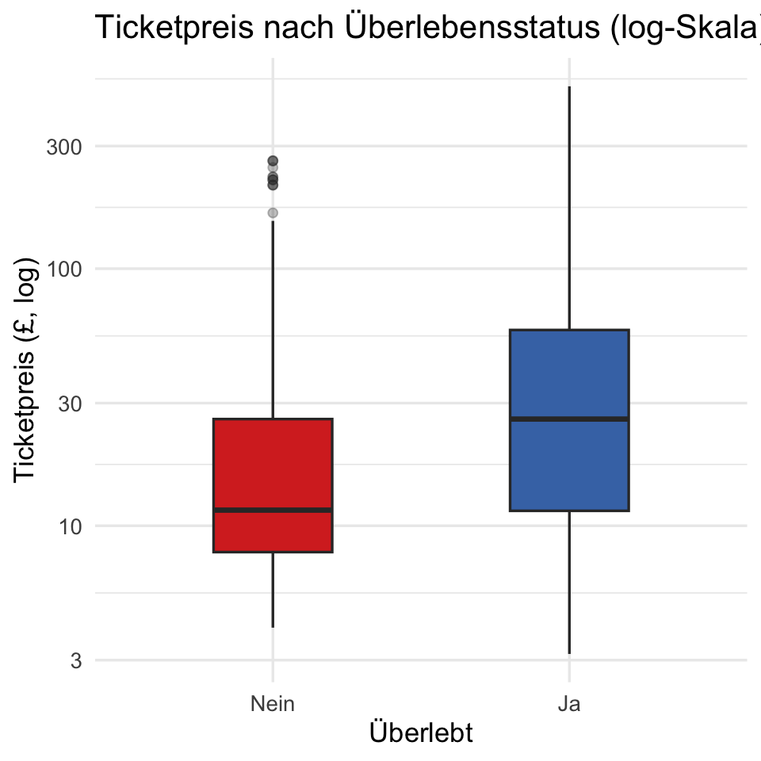

```r
titanic |>
  filter(!is.na(fare)) |>
  ggplot(aes(x = survived, y = fare, fill = survived)) +
  geom_boxplot(width = 0.4, outlier.alpha = 0.3) +
  scale_fill_manual(values = c("Nein" = "#d73027", "Ja" = "#4575b4")) +
  scale_y_log10() +
  labs(title = "Ticketpreis nach Überlebensstatus (log-Skala)",
       x = "Überlebt", y = "Ticketpreis (£, log)") +
  theme_minimal(base_size = 13) +
  theme(legend.position = "none")
```

> Überlebende zahlten im Schnitt signifikant mehr (p < .05) – ein Hinweis auf den Einfluss der Klasse.

### 4.2 Chi-Quadrat-Test: Geschlecht und Überleben

**Forschungsfrage:** Hängt das Überleben vom Geschlecht ab?

- H₀: Geschlecht und Überleben sind unabhängig voneinander.
- H₁: Es gibt einen Zusammenhang.

```r
tab <- table(titanic$sex, titanic$survived)
tab
```

```
##
##            Nein  Ja
##   weiblich  127 339
##   männlich  682 161
```

```r
chisq.test(tab)
```

```
##
##  Pearson's Chi-squared test with Yates' continuity correction
##
## data:  tab
## X-squared = 363.62, df = 1, p-value < 2.2e-16
```

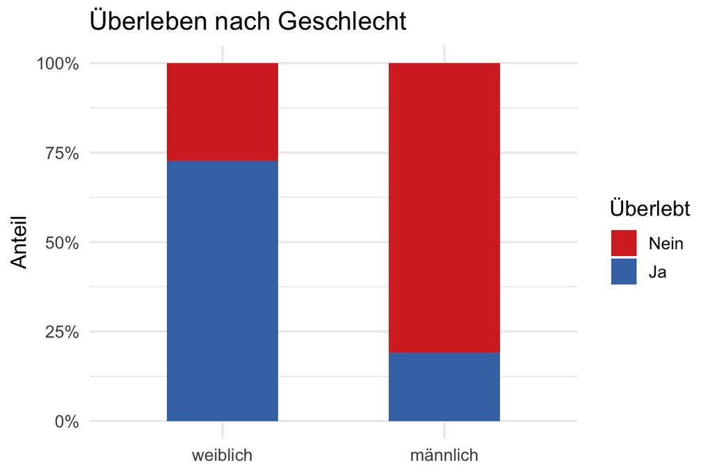

```r
as.data.frame(tab) |>
  rename(Geschlecht = Var1, Überlebt = Var2) |>
  group_by(Geschlecht) |>
  mutate(Anteil = Freq / sum(Freq)) |>
  ggplot(aes(x = Geschlecht, y = Anteil, fill = Überlebt)) +
  geom_col(position = "fill", width = 0.5) +
  scale_y_continuous(labels = scales::percent) +
  scale_fill_manual(values = c("Nein" = "#d73027", "Ja" = "#4575b4")) +
  labs(title = "Überleben nach Geschlecht", x = NULL, y = "Anteil") +
  theme_minimal(base_size = 13)
```

> Der Chi-Quadrat-Test zeigt einen hochsignifikanten Zusammenhang (p < .001): Frauen überlebten deutlich häufiger als Männer (“Women and children first”).

### 4.3 Korrelation: Alter und Ticketpreis

**Forschungsfrage:** Gibt es einen Zusammenhang zwischen dem Alter eines Passagiers und dem bezahlten Ticketpreis?

```r
titanic_clean <- titanic |> filter(!is.na(age), !is.na(fare))

cor.test(titanic_clean$age, titanic_clean$fare, method = "pearson")
```

```
##
##  Pearson's product-moment correlation
##
## data:  titanic_clean$age and titanic_clean$fare
## t = 5.867, df = 1043, p-value = 5.955e-09
## alternative hypothesis: true correlation is not equal to 0
## 95 percent confidence interval:
##  0.1193904 0.2368155
## sample estimates:
##       cor
## 0.1787393
```

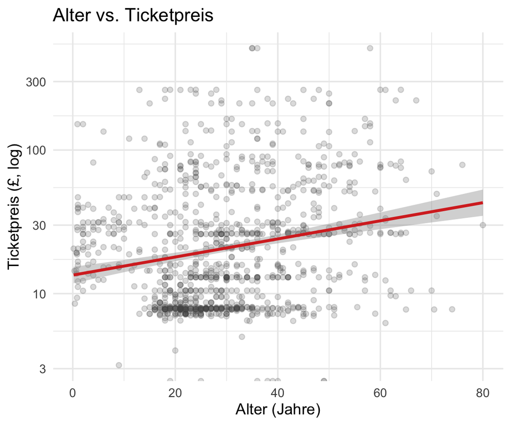

```r
ggplot(titanic_clean, aes(x = age, y = fare)) +
  geom_point(alpha = 0.2, color = "#555555") +
  geom_smooth(method = "lm", color = "#d73027", se = TRUE) +
  scale_y_log10() +
  labs(title = "Alter vs. Ticketpreis",
       x = "Alter (Jahre)", y = "Ticketpreis (£, log)") +
  theme_minimal(base_size = 13)
```

### 4.4 Logistische Regression: Was beeinflusst das Überleben?

**Forschungsfrage:** Welchen Einfluss haben Geschlecht, Klasse und Alter auf die Überlebenswahrscheinlichkeit?

```r
titanic_logit <- titanic |>
  filter(!is.na(age)) |>
  mutate(survived_bin = ifelse(survived == "Ja", 1, 0))

modell <- glm(survived_bin ~ sex + pclass + age,
              data   = titanic_logit,
              family = binomial)

summary(modell)
```

```
##
## Call:
## glm(formula = survived_bin ~ sex + pclass + age, family = binomial,
##     data = titanic_logit)
##
## Coefficients:
##                  Estimate Std. Error z value Pr(>|z|)
## (Intercept)      3.522074   0.326702  10.781  < 2e-16 ***
## sexmännlich     -2.497845   0.166037 -15.044  < 2e-16 ***
## pclass2. Klasse -1.280570   0.225538  -5.678 1.36e-08 ***
## pclass3. Klasse -2.289661   0.225802 -10.140  < 2e-16 ***
## age             -0.034393   0.006331  -5.433 5.56e-08 ***
## ---
## Signif. codes:  0 '***' 0.001 '**' 0.01 '*' 0.05 '.' 0.1 ' ' 1
##
## (Dispersion parameter for binomial family taken to be 1)
##
##     Null deviance: 1414.62  on 1045  degrees of freedom
## Residual deviance:  982.45  on 1041  degrees of freedom
## AIC: 992.45
##
## Number of Fisher Scoring iterations: 4
```

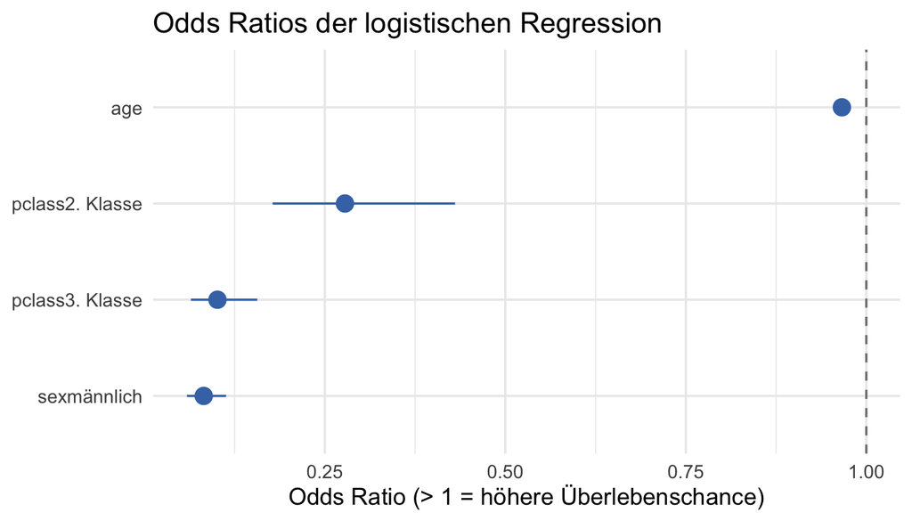

```r
# Odds Ratios visualisieren
broom::tidy(modell, exponentiate = TRUE, conf.int = TRUE) |>
  filter(term != "(Intercept)") |>
  ggplot(aes(x = reorder(term, estimate), y = estimate,
             ymin = conf.low, ymax = conf.high)) +
  geom_pointrange(color = "#4575b4", size = 0.8) +
  geom_hline(yintercept = 1, linetype = "dashed", color = "grey50") +
  coord_flip() +
  labs(title = "Odds Ratios der logistischen Regression",
       x = NULL, y = "Odds Ratio (> 1 = höhere Überlebenschance)") +
  theme_minimal(base_size = 13)
```

> Das Geschlecht hat den stärksten Einfluss: Männer hatten eine deutlich geringere Überlebenschance als Frauen (OR für `sexmännlich` ≈ 0.08, also weit unter 1). Auch 2. und 3. Klasse (vs. 1. Klasse) sowie höheres Alter reduzierten die Überlebenswahrscheinlichkeit signifikant.

## 5 Zusammenfassung

[output not shown]

*Hinweis: Dieser Datensatz enthält nur Passagiere, zu denen Daten vorlagen. Besatzungsmitglieder sind nicht enthalten.*